# Graph-Poset-Zeta-Mobius-Theta-Eta

ryamada

2018年8月28日

# 連結グラフ

連結グラフ $G=(V,E)$を考える。

$$G = (V,E)$$

適当に連結グラフ$G$を作る。

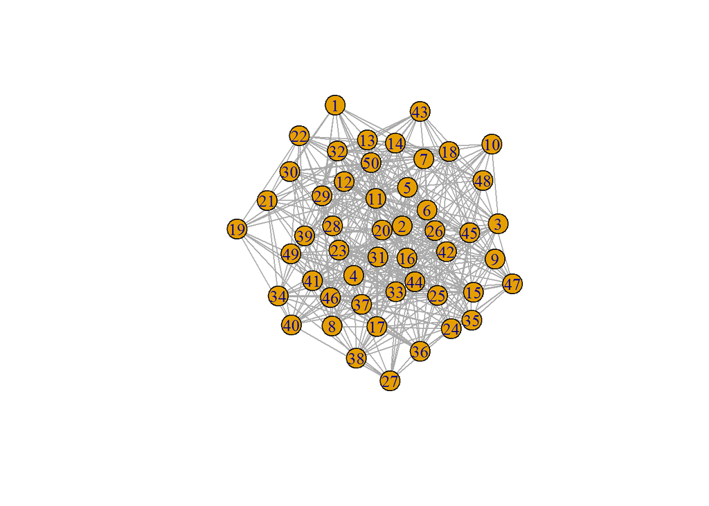

```r
library(igraph)
nv <- 50
loop <- TRUE
while(loop){
  t <- runif(1) + 1
  A <- matrix(runif(nv^2),nv,nv)
  A <- A + t(A)
  diag(A) <- 0
  A <- matrix(A > t, nv,nv) + 0
  g <- graph.adjacency(A,mode="undirected")
  if(is.connected(g)){
    loop <- FALSE
  }
}
plot(g)
```

# ポセットを作る

ルートノード$\rho$を選び、$G$からポセット$S_{\rho}^G = (S=V,\le)_{\rho}^G$を作成する。

$\rho$からのグラフ距離$D_{\rho}$を算出。

エッジの向きを$D_{\rho}$に基づいて定める。

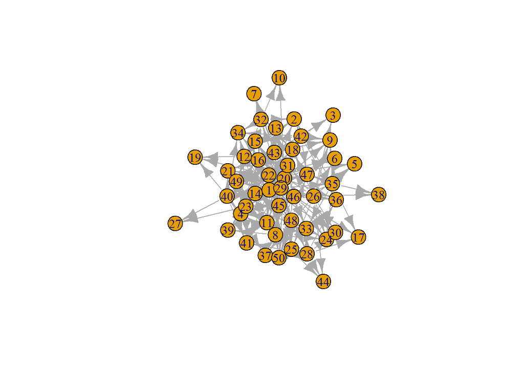

```r
nv <- length(V(g))
rho <- sample(1:nv,1)
D_rho <- distances(g,v=rho)
A_poset <- A
for(i in 1:nv){
  for(j in 1:nv){
    if(D_rho[i] >= D_rho[j]){
      A_poset[i,j] <- 0
    }
  }
}
g_poset <- graph.adjacency(A_poset)
plot(g_poset)
```

# $\zeta$行列 $\zeta : S\times S \to \{0,1\}$

```r
zeta <- distances(g_poset,mode="out")
zeta
```

```
##       [,1] [,2] [,3] [,4] [,5] [,6] [,7] [,8] [,9] [,10] [,11] [,12] [,13]
##  [1,]    0    1  Inf  Inf  Inf  Inf  Inf  Inf  Inf   Inf     1   Inf     1
##  [2,]  Inf    0  Inf  Inf  Inf  Inf  Inf  Inf  Inf   Inf   Inf   Inf   Inf
##  [3,]  Inf  Inf    0  Inf  Inf  Inf  Inf  Inf  Inf   Inf   Inf   Inf   Inf
##  [4,]  Inf  Inf  Inf    0  Inf  Inf  Inf  Inf  Inf   Inf   Inf   Inf   Inf
##  [5,]  Inf  Inf  Inf  Inf    0  Inf  Inf  Inf  Inf   Inf   Inf   Inf   Inf
##  [6,]  Inf  Inf  Inf  Inf  Inf    0  Inf  Inf  Inf   Inf   Inf   Inf   Inf
##  [7,]  Inf  Inf  Inf  Inf  Inf  Inf    0  Inf  Inf   Inf   Inf   Inf   Inf
##  [8,]  Inf  Inf  Inf    1  Inf  Inf  Inf    0  Inf   Inf     1   Inf   Inf
##  [9,]  Inf  Inf  Inf  Inf  Inf  Inf  Inf  Inf    0   Inf   Inf   Inf   Inf
## [10,]  Inf  Inf  Inf  Inf  Inf  Inf  Inf  Inf  Inf     0   Inf   Inf   Inf
## [11,]  Inf  Inf  Inf  Inf  Inf  Inf  Inf  Inf  Inf   Inf     0   Inf   Inf
## [12,]  Inf    1  Inf    1  Inf  Inf  Inf  Inf  Inf   Inf   Inf     0   Inf
## [13,]  Inf  Inf  Inf  Inf  Inf  Inf  Inf  Inf  Inf   Inf   Inf   Inf     0
## [14,]  Inf  Inf  Inf  Inf  Inf  Inf  Inf  Inf  Inf   Inf   Inf   Inf   Inf
```

[output cut: 240 more lines]

```r
zeta[which(is.infinite(zeta))] <- 0
zeta <- matrix(zeta>0,nv,nv) + 0
zeta
```

```
##       [,1] [,2] [,3] [,4] [,5] [,6] [,7] [,8] [,9] [,10] [,11] [,12] [,13]
##  [1,]    0    1    0    0    0    0    0    0    0     0     1     0     1
##  [2,]    0    0    0    0    0    0    0    0    0     0     0     0     0
##  [3,]    0    0    0    0    0    0    0    0    0     0     0     0     0
##  [4,]    0    0    0    0    0    0    0    0    0     0     0     0     0
##  [5,]    0    0    0    0    0    0    0    0    0     0     0     0     0
##  [6,]    0    0    0    0    0    0    0    0    0     0     0     0     0
##  [7,]    0    0    0    0    0    0    0    0    0     0     0     0     0
##  [8,]    0    0    0    1    0    0    0    0    0     0     1     0     0
##  [9,]    0    0    0    0    0    0    0    0    0     0     0     0     0
## [10,]    0    0    0    0    0    0    0    0    0     0     0     0     0
## [11,]    0    0    0    0    0    0    0    0    0     0     0     0     0
## [12,]    0    1    0    1    0    0    0    0    0     0     0     0     0
## [13,]    0    0    0    0    0    0    0    0    0     0     0     0     0
## [14,]    0    0    0    0    0    0    0    0    0     0     0     0     0
```

[output cut: 240 more lines]

```r
diag(zeta) <- 1
zeta
```

```
##       [,1] [,2] [,3] [,4] [,5] [,6] [,7] [,8] [,9] [,10] [,11] [,12] [,13]
##  [1,]    1    1    0    0    0    0    0    0    0     0     1     0     1
##  [2,]    0    1    0    0    0    0    0    0    0     0     0     0     0
##  [3,]    0    0    1    0    0    0    0    0    0     0     0     0     0
##  [4,]    0    0    0    1    0    0    0    0    0     0     0     0     0
##  [5,]    0    0    0    0    1    0    0    0    0     0     0     0     0
##  [6,]    0    0    0    0    0    1    0    0    0     0     0     0     0
##  [7,]    0    0    0    0    0    0    1    0    0     0     0     0     0
##  [8,]    0    0    0    1    0    0    0    1    0     0     1     0     0
##  [9,]    0    0    0    0    0    0    0    0    1     0     0     0     0
## [10,]    0    0    0    0    0    0    0    0    0     1     0     0     0
## [11,]    0    0    0    0    0    0    0    0    0     0     1     0     0
## [12,]    0    1    0    1    0    0    0    0    0     0     0     1     0
## [13,]    0    0    0    0    0    0    0    0    0     0     0     0     1
## [14,]    0    0    0    0    0    0    0    0    0     0     0     0     0
```

[output cut: 240 more lines]

関数化しておく

```r
my.zeta <- function(g,rho){
  D_rho <- distances(g,v=rho)
  A_poset <- A
  for(i in 1:nv){
    for(j in 1:nv){
      if(D_rho[i] >= D_rho[j]){
        A_poset[i,j] <- 0
      }
    }
  }
  g_poset <- graph.adjacency(A_poset)
  zeta <- distances(g_poset,mode="out")
  zeta[which(is.infinite(zeta))] <- 0
  zeta <- matrix(zeta>0,nv,nv) + 0
  diag(zeta) <- 1
  return(zeta)
}
```

# $G$上の確率質量分布$P$

```r
library(MCMCpack)
P <- c(rdirichlet(1,rep(1,nv)))
P
```

```
##  [1] 3.498165e-02 8.456769e-03 2.066252e-02 1.134702e-02 2.316313e-03
##  [6] 1.436665e-03 5.798924e-02 4.445081e-03 7.575299e-03 1.756011e-02
## [11] 1.595726e-02 4.666861e-03 3.724326e-04 1.906281e-02 1.051545e-02
## [16] 3.486312e-03 7.061924e-03 2.124125e-02 2.220566e-04 1.953985e-02
## [21] 3.696820e-02 3.224338e-02 1.642043e-03 7.325343e-02 2.990738e-02
## [26] 2.893482e-03 8.902399e-02 2.607111e-02 2.772153e-02 2.547014e-02
## [31] 1.597224e-03 6.959719e-03 7.877302e-03 1.887411e-02 6.232471e-02
## [36] 3.640571e-02 1.976004e-02 1.545650e-03 1.476469e-02 3.669753e-03
## [41] 9.941535e-05 1.836440e-02 5.809485e-02 9.049955e-03 3.971690e-02
## [46] 1.587008e-04 2.153454e-02 3.557872e-03 2.077007e-02 4.078284e-02
```

```r
sum(P)
```

```
## [1] 1
```

# $\theta$座標

$$\log{P(v)} = \sum_{s \in S} \zeta(s,v) \theta(s)\\
= \zeta_{matrix} \theta(s)$$
であるから

$$\theta(s) = \zeta_{matrix}^{-1} \log{P(v)}$$

```r
theta <- solve(zeta) %*% log(P)
theta
```

```
##              [,1]
##  [1,]   39.256229
##  [2,]   -4.772788
##  [3,]   -3.879434
##  [4,]   -4.478800
##  [5,]   -6.067778
##  [6,]   -6.545431
##  [7,]   -2.847498
##  [8,]   33.118505
##  [9,]   -4.882863
## [10,]   -4.042125
## [11,]   -4.137841
## [12,]   38.299064
## [13,]   -7.895454
## [14,]   -3.960016
```

[output cut: 36 more lines]

検算

```r
log(P) - zeta %*% theta
```

```
##                [,1]
##  [1,] -3.996803e-15
##  [2,]  0.000000e+00
##  [3,]  0.000000e+00
##  [4,]  0.000000e+00
##  [5,]  0.000000e+00
##  [6,]  0.000000e+00
##  [7,]  0.000000e+00
##  [8,] -8.881784e-16
##  [9,]  0.000000e+00
## [10,]  0.000000e+00
## [11,]  0.000000e+00
## [12,] -4.440892e-15
## [13,]  0.000000e+00
## [14,]  0.000000e+00
```

[output cut: 36 more lines]

# Mobius行列

Mobius関数$\mu$はzeta関数の逆関数だから、Mobius行列はzeta行列の逆行列

```r
mobius <- solve(zeta)
mobius
```

```
##       [,1] [,2] [,3] [,4] [,5] [,6] [,7] [,8] [,9] [,10] [,11] [,12] [,13]
##  [1,]    1   -1    0    0    0    0    0    0    0     0    -1     0    -1
##  [2,]    0    1    0    0    0    0    0    0    0     0     0     0     0
##  [3,]    0    0    1    0    0    0    0    0    0     0     0     0     0
##  [4,]    0    0    0    1    0    0    0    0    0     0     0     0     0
##  [5,]    0    0    0    0    1    0    0    0    0     0     0     0     0
##  [6,]    0    0    0    0    0    1    0    0    0     0     0     0     0
##  [7,]    0    0    0    0    0    0    1    0    0     0     0     0     0
##  [8,]    0    0    0   -1    0    0    0    1    0     0    -1     0     0
##  [9,]    0    0    0    0    0    0    0    0    1     0     0     0     0
## [10,]    0    0    0    0    0    0    0    0    0     1     0     0     0
## [11,]    0    0    0    0    0    0    0    0    0     0     1     0     0
## [12,]    0   -1    0   -1    0    0    0    0    0     0     0     1     0
## [13,]    0    0    0    0    0    0    0    0    0     0     0     0     1
## [14,]    0    0    0    0    0    0    0    0    0     0     0     0     0
```

[output cut: 240 more lines]

# $\eta$を求める

$$P(v) = \sum_{s \in S} \mu(s,v) \eta(s)\\
= \mu_{matrix} \theta(s)$$

したがって

$$\eta(s) = \mu_{matrix}^{-1} P(v)\\
=\zeta_{matrix} P(v)$$

```r
eta <- zeta %*% P
eta
```

```
##               [,1]
##  [1,] 1.448550e-01
##  [2,] 8.456769e-03
##  [3,] 2.066252e-02
##  [4,] 1.134702e-02
##  [5,] 2.316313e-03
##  [6,] 1.436665e-03
##  [7,] 5.798924e-02
##  [8,] 1.987789e-01
##  [9,] 7.575299e-03
## [10,] 1.756011e-02
## [11,] 1.595726e-02
## [12,] 1.357005e-01
## [13,] 3.724326e-04
## [14,] 1.906281e-02
```

[output cut: 36 more lines]

検算

```r
mobius %*% eta - P
```

```
##                [,1]
##  [1,] -3.469447e-17
##  [2,]  0.000000e+00
##  [3,]  0.000000e+00
##  [4,]  0.000000e+00
##  [5,]  0.000000e+00
##  [6,]  0.000000e+00
##  [7,]  0.000000e+00
##  [8,] -8.673617e-18
##  [9,]  0.000000e+00
## [10,]  0.000000e+00
## [11,]  0.000000e+00
## [12,]  7.806256e-18
## [13,]  0.000000e+00
## [14,]  0.000000e+00
```

[output cut: 36 more lines]

# $\rho$を取り替えてみる

$\rho$を$1,2,...,|V|$に取り替えて、それぞれの $\Theta,\Eta,\zeta,\mu$を算出することにする

```r
thetas <- etas <- zetas <- mus <- list()
for(i in 1:nv){
  zetas[[i]] <- my.zeta(g,i)
  mus[[i]] <- solve(zetas[[i]])
  #thetas[[i]] <- solve(zetas[[i]]) %*% log(P)
  thetas[[i]] <- mus[[i]] %*% log(P)
  etas[[i]] <- zetas[[i]] %*% P
}
```

これにより$|V|$通りの、$\Theta,\Eta,\zeta,\mu$が生成された。

$$\log{P(v)} = \zeta_{\rho=q} \theta_{\rho=q} = \zeta_{\rho=r} \theta_{\rho=r}\\
P(v) = \mu_{\rho=q} \eta_{\rho=q} = \mu_{\rho=r} \eta_{\rho=r}$$
が成り立つから、

$\theta_q$と$\theta_r$とは線形変換。

これは、$\theta,\eta$座標系がAffine変換を除いて一意に決まる、という話と通じている。

検算

```r
thetas[[1]] - solve(zetas[[1]]) %*% zetas[[2]] %*% thetas[[2]]
```

```
##                [,1]
##  [1,]  1.705303e-13
##  [2,]  9.947598e-14
##  [3,]  0.000000e+00
##  [4,]  0.000000e+00
##  [5,]  1.776357e-15
##  [6,]  6.217249e-15
##  [7,] -3.108624e-15
##  [8,]  0.000000e+00
##  [9,]  0.000000e+00
## [10,] -8.881784e-16
## [11,] -2.842171e-14
## [12,]  2.131628e-14
## [13,]  1.421085e-14
## [14,]  0.000000e+00
```

[output cut: 36 more lines]

```r
etas[[1]] - solve(mus[[1]]) %*% mus[[3]] %*% etas[[3]]
```

```
##                [,1]
##  [1,]  0.000000e+00
##  [2,] -3.885781e-16
##  [3,]  1.075529e-16
##  [4,] -1.734723e-18
##  [5,]  0.000000e+00
##  [6,]  5.464379e-17
##  [7,] -6.938894e-18
##  [8,]  0.000000e+00
##  [9,]  0.000000e+00
## [10,] -3.469447e-18
## [11,]  5.551115e-17
## [12,] -1.110223e-16
## [13,] -1.665335e-16
## [14,] -1.665335e-16
```

[output cut: 36 more lines]

このことは、グラフGにある一つのポセットSを選んで、$\theta,\eta,\zeta,\mu$を取り出して把握した「何か」は、ノード数だけバリエーションがあるが、それは表面的な違いであって、本質的な違いではないことを意味している。

２つのグラフがあったときに、それぞれ、勝手にルートノードを決め、対応するポセットについて何かをしたとする。

限定された線形変換で、そのポセットに対応する$\theta,\eta,\zeta,\mu$が一致させられれば、そのグラフは「同じ」で、そうできなければ、「違う」ということなわけだけれど、この「異同」を決める「限定された線形変換」って何なのでしょう？